## Análise de serie temporal usando SSA e Rede Neural

#### Walter Humberto Subiza Pina - Instituto Brasileiro de Geografia e Estatística

#### Pedro Costa Ferreira - Fundação Getúlio Vargas

#### José Francisco Moreira Pessanha - Universidade do Estado do Rio de Janeiro

O propósito do trabalho é apresentar o análise de uma série temporal de dados com duas metodologias diferentes, SSA e Rede Neural, assim como fazer uma previsão de comportamento da variável a futuro.

A serie temporal a ser analisada tem dados sobre o volume de vendas do comercio varejista ampliado (VVCVA) entre Janeiro de 2003 e Dezembro de 2011. A serie inclue além do comercio varejista, os setores de “Veículos, motocicletas, partes e peças” e “Material de construção”. A categoria selecionada foi de Indice de base fixa com 2003 = 100.

Serie pode ser baixada de [Séries Estatísticas IBGE](http://seriesestatisticas.ibge.gov.br/series.aspx?no=2&op=0&vcodigo=MC67&t=volume-vendas-comercio-varejista-ampliado-tipos) , e foi extraída em 09/02/2018.

### Carregar pacotes necessários ao análise

carregando arquivo de dados

```r
vendas <- read.csv("data/IBGE_VVCVA.csv",
                   header = FALSE,
                   stringsAsFactors = F)

#transposição de linha a coluna em dataframe
vendas2 <- as.data.frame(t(vendas))

# transformação em st_Vendas temporal
st_Vendas <- ts(vendas2,
                start     = c(2003,1),
                frequency = 12)
```

Preparando a ST para análise

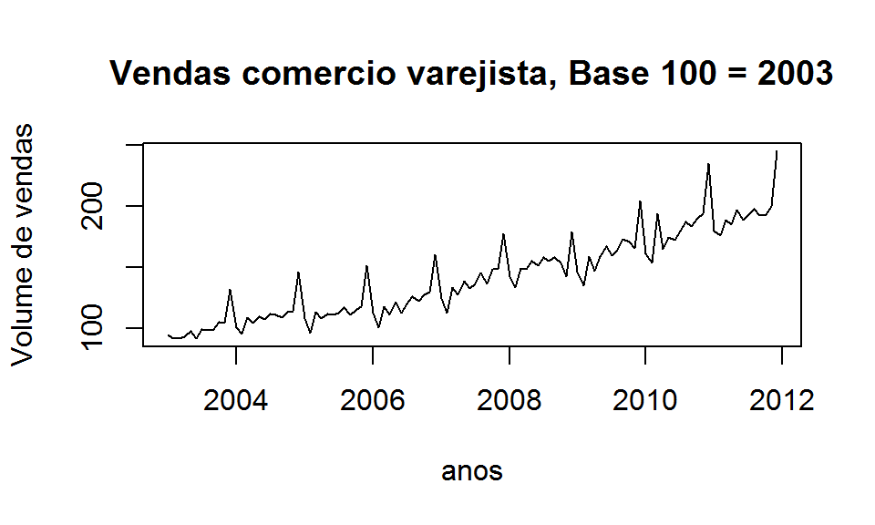

```r
plot (st_Vendas,
     xlab = "anos",
     ylab = "Volume de vendas",
     main = "Vendas comercio varejista, Base 100 = 2003")
```

Vamos analisar graficamente a sazonalidade e determinar os meses em que as variações são máximas e mínimas

```r
dygraph (st_Vendas)
```

[interactive chart not shown]

Se observa que a série tem uma **tendencia crescente** ao longo do tempo, com **variação sazonal forte nos meses de dezembro e fevereiro** de cada ano

Ao aplicar a funçao `log` na série, vamos a estacionar a variância primeiramente.

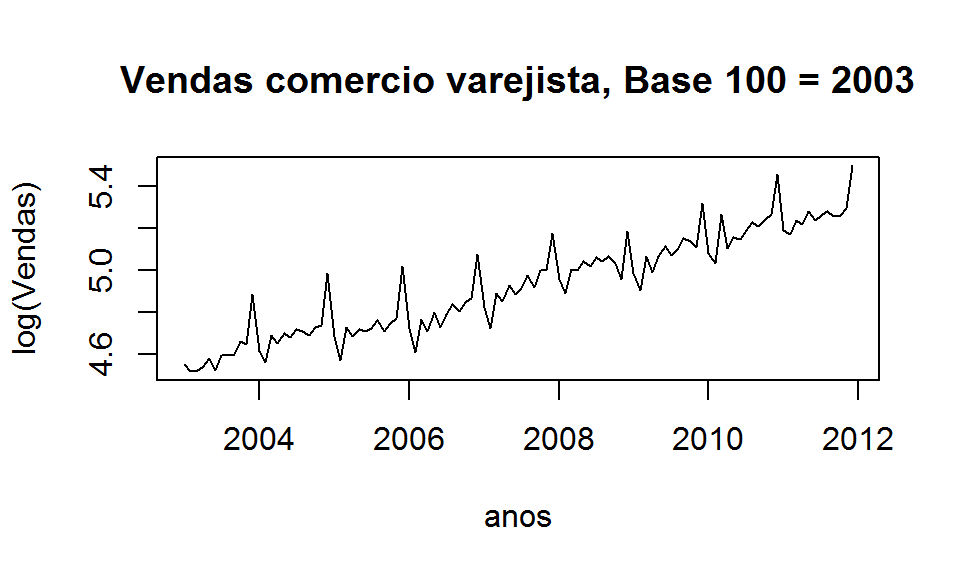

```r
# n?mero de observa??es
n <-  length(st_Vendas)

#
logst_Vendas <-  log(st_Vendas)

plot (logst_Vendas,
     xlab = "anos",
     ylab = "log(Vendas)",
     main = "Vendas comercio varejista, Base 100 = 2003")
```

A tendencia da série, será retirada fazendo uma diferença entre observações com lag=1 e diferenças de primeira ordem

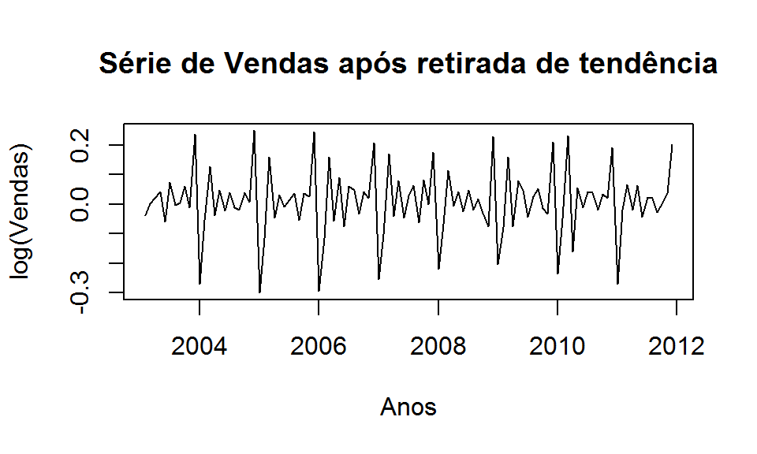

```r
delta <- diff(logst_Vendas, lag = 1, differences = 1)

plot (delta,
     xlab = "Anos",
     ylab = "log(Vendas)",
     main = " Série de Vendas após retirada de tendência ")
```

*Normalização da série* para deixar ela entre 0 e 1

```r
maximo <- max(delta)
minimo <- min(delta)
normalizado <- (delta - minimo) / (maximo - minimo)
```

PREPARA CONJUNTO DE PADROES ENTRADA/SAIDA

Os lags definidos são o valor prévio (1), o segundo valor anterior (2), o quarto valor anterior (4) e o 12 valor anterior (12), caraterizando um modelo que leva em conta os dois meses anteriores, o valor do trimestre e do ano. O arquivo de saída vair ter 4 variáveis explicativas (X1 a X4) e 1 de resposta (Y), exemplo:

| X1 | X2 | X3 | X4 | Y |
| --- | --- | --- | --- | --- |
| Jan04 | Dec03 | Out03 | Fev03 | Fev04 |
| Fev04 | Jan04 | Nov03 | Mar03 | Mar04 |
| … | … | … | … | … |
| … | … | … | … | … |

```r
lags <- c(1,2,4,12) # INFORME OS LAGS
inic <- max(lags) + 1 # inicar em 13

nobs <- length(normalizado) # número de observações: 107

# iniciar vetores nulos
inputs <- c() # PADROES DE ENTRADA
output <- c() # PADROES DE SAIDA
indice <- c() # posição de cada output no tempo

# iteração que preenche os vetores com as observações

for (i in inic:nobs) {
  inputs = rbind(inputs, normalizado[i - lags])
  output = c(output, normalizado[i])
  indice = c(indice, i+1)

data.train <- cbind(inputs, output) # PADRÕES ENTRADA/SAÍDA

nomes <- c()
for(i in 1:length(lags)) {
  nomes[i] = paste("X", i, sep = "")
  }

colnames(data.train) = c(nomes,"Y")

limites <- c(0, 1)
p       <- dim(inputs)[2] + 1 # n?mero de vari?veis no modelo

#original tem um p demais
#range.data <- matrix(rep(limites,p),2,p) # intervalo de cada vari?vel
range.data <- matrix(rep(limites, p), 2)
}
```

SELECIONA AMOSTRAS TREINO E TESTE

```r
npadroes   <- dim(data.train)[1] # calcula o número de padrões para o análise: 95

noutsample <- 12 # escolhe o tamanho da previsão...12

ninsample  <- npadroes - noutsample # número de padrões de treino
```

#### Processamento da ST com rede neural, usando o pacote `neuralnet` versão 1.33. O pacote treina redes neurais com `backpropagation`

TREINA REDE FEEDFORWARD

```r
modelo_nn <- neuralnet(formula     = Y ~ X1 + X2 + X3 + X4,
                 data              = data.train[1:ninsample,],
                 hidden            = 8,
                 linear.output    = F)
```

## Gráfico da rede neural

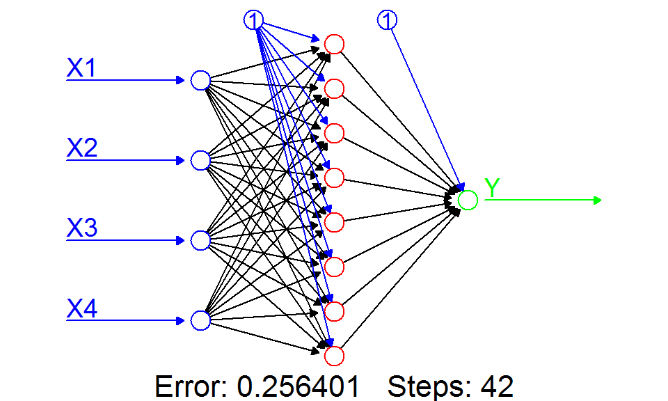

```r
plot(modelo_nn,
     rep               = "best",
     col.hidden        = "red",
     col.entry         = "blue",
     col.entry.synapse = "blue",
     col.out           = "green",
     col.out.synapse   = "green",
     show.weights      = F,
     fontsize          = 14)
```

PREVISÃO INSAMPLE

Essa previsão vai servir para testar a precisão do modelo calculado

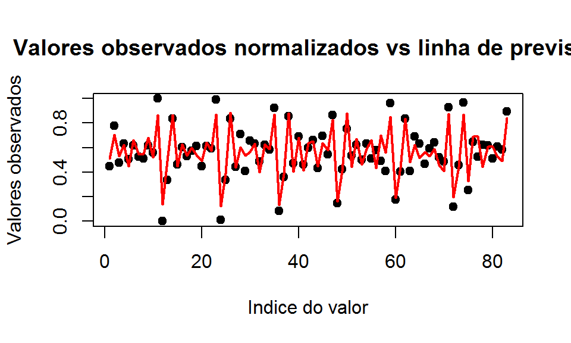

```r
previsao <- compute (modelo_nn,
                 inputs[1:ninsample,])$net.result

plot (output[1: ninsample],
     xlab = "Indice do valor",
     ylab = "Valores observados",
     main = "Valores observados normalizados vs linha de previsão",
     pch  = 19)

lines (1:ninsample,
      previsao,
      lwd = 2,
      col = "red")
```

Vamos agora fazer a previsão da série sobre o log de valores reais 1 passo a frente

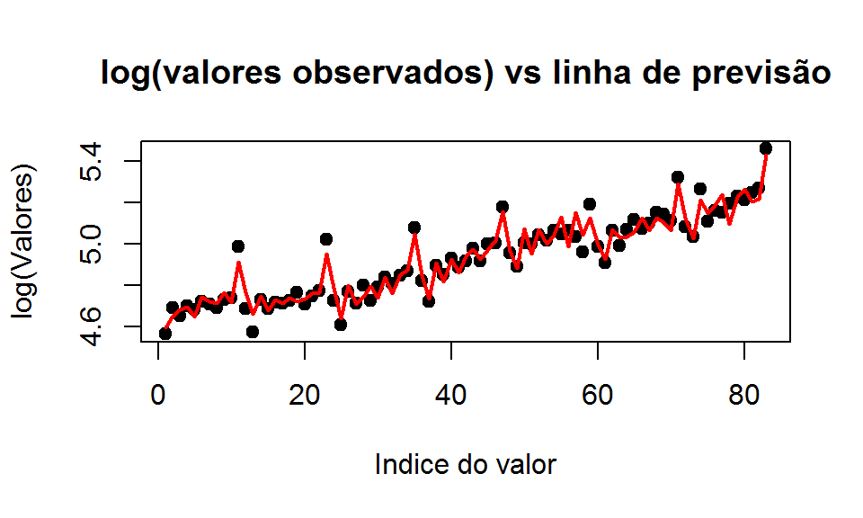

```r
previsaolog <- c()
for (i in 1:ninsample) {
  x0          = logst_Vendas[indice[i]-1]
  cumprevisao = x0 + previsao[i] * (maximo-minimo) + minimo
  previsaolog = c(previsaolog,cumprevisao)
}

plot(logst_Vendas[indice[1]:indice[ninsample]],
     xlab = "Indice do valor",
     ylab = "log(Valores)",
     main = "log(valores observados) vs linha de previsão",
     pch  = 19)

lines(1:ninsample,
      previsaolog,
      lwd = 2,
      col = "red")
```

Previsão de vendas do comercio varejista 1 passo a frente

```r
previsao_vendas_treino = exp(previsaolog)

MAD_INSAMPLE = round(mean(abs(st_Vendas[indice[1]:indice[ninsample]] - previsao_vendas_treino)),2)

MAPE_INSAMPLE = round(100*mean(abs(st_Vendas[indice[1]:indice[ninsample]] -
                                     previsao_vendas_treino)/st_Vendas[indice[1]:indice[ninsample]]),2)
```

Plotagem da série com indicadores de preciséo

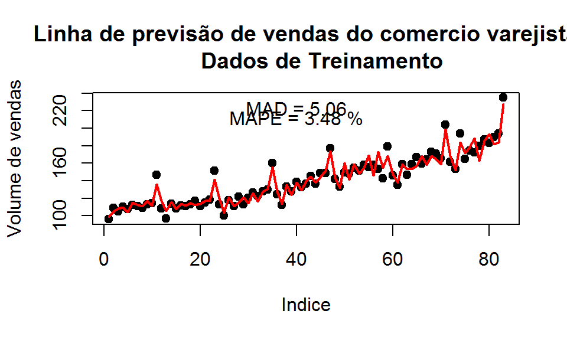

```r
x_plot  <- mean(indice[1]:indice[ninsample])-15

y_plot  <- max(st_Vendas[indice[1]:indice[ninsample]])*.95

y_plot2 <- y_plot*.95

plot (st_Vendas[indice[1]:indice[ninsample]],
     xlab = "Indice",
     ylab = "Volume de vendas",
     main = "Linha de previsão de vendas do comercio varejista
     Dados de Treinamento",
     pch  = 19)

lines (1:ninsample,
      previsao_vendas_treino,
      lwd = 2,
      col = "red")

text(x_plot,y_plot, paste0("MAD = ",MAD_INSAMPLE))

text(x_plot,y_plot2, paste0("MAPE = ",MAPE_INSAMPLE," %"))
```

PREVISÃO OUTSAMPLE

Vamos fazer agora a previsão sobre os valores que não foram usados para treinar o modelo, ou seja os últimos 12 valores do ano 2011 (indices 84 a 95 dos dados de data.train) previsão da diferença do log

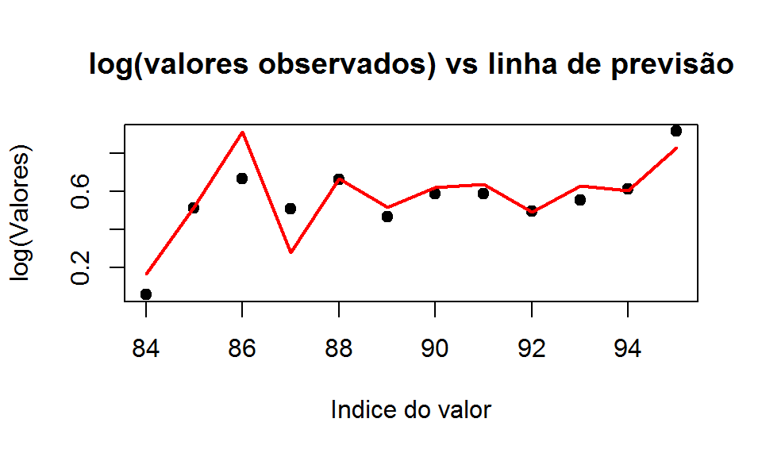

```r
previsao_vendas_teste <- compute(modelo_nn,
                                 inputs[(ninsample + 1):(ninsample + noutsample),])$net.result

plot((ninsample + 1):(ninsample + noutsample),
     output[(ninsample + 1):(ninsample + noutsample)],
     xlab = "Indice do valor",
     ylab = "log(Valores)",
     main = "log(valores observados) vs linha de previsão",
     pch  = 19)

lines((ninsample+1):(ninsample+noutsample),
      previsao_vendas_teste,
      lwd = 2,
      col = "red")
```

previsão do log 1 passo a frente

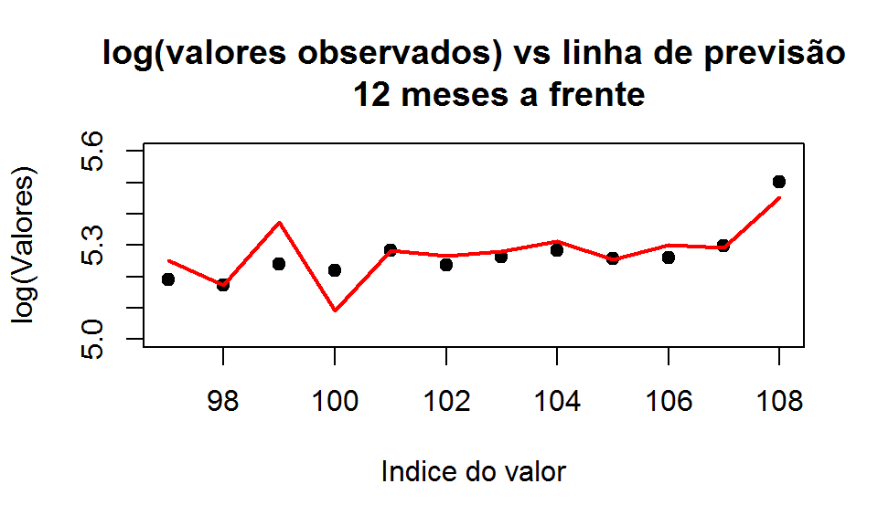

```r
previsaolog = c()
for (i in (ninsample+1):(ninsample + noutsample)){
  x0          = logst_Vendas[indice[i] - 1]
  cumprevisao = x0 + previsao_vendas_teste[i-ninsample]*(maximo-minimo)+minimo
  previsaolog = c(previsaolog,cumprevisao)}


plot(indice[ninsample+1]:indice[ninsample+noutsample],
     logst_Vendas[indice[ninsample+1]:indice[ninsample+noutsample]],
     ylim = c(5,5.6),
     xlab = "Indice do valor",
     ylab = "log(Valores)",
     main = "log(valores observados) vs linha de previsão
     12 meses a frente",
     pch  = 19)

lines(indice[ninsample+1]:indice[ninsample+noutsample],
      previsaolog,
      lwd = 2,
      col = "red")
```

previsão de vendas 1 passo a frente

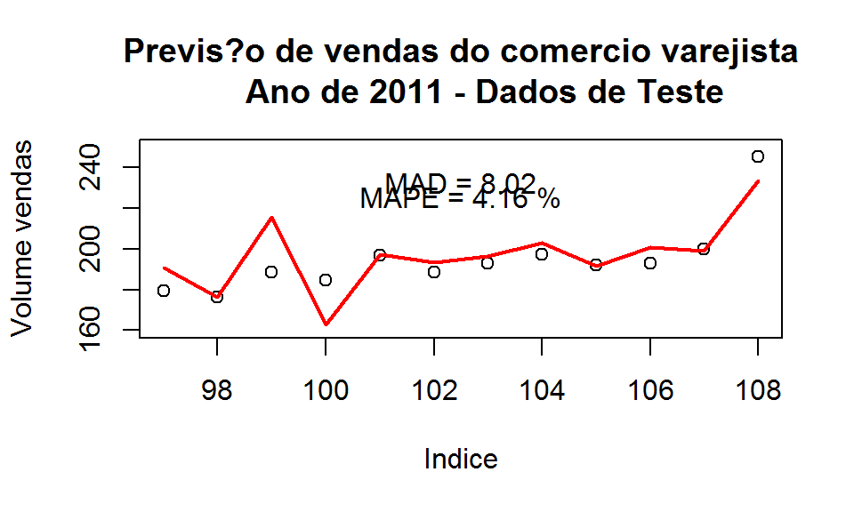

```r
previsao_vendas_futuro <- exp(previsaolog)

MAD  <- round(mean(abs(st_Vendas[indice[ninsample + 1]:indice[ninsample + noutsample]] -
                       previsao_vendas_futuro)),2)
MAPE <- round(100*mean(abs(st_Vendas[indice[ninsample +1 ]:indice[ninsample + noutsample]] -
                            previsao_vendas_futuro) / st_Vendas[indice[ninsample + 1]:indice[ninsample+noutsample]]),2)

# coordenadas de plotagem dos indicadores de qualidade
x_plot <- mean(indice[ninsample+1]:indice[ninsample+noutsample])

y_plot <- max(st_Vendas[indice[ninsample+1]:indice[ninsample+noutsample]])*.95

y_plot2 <- y_plot*.97


plot (indice[ninsample+1]:indice[ninsample+noutsample],
     st_Vendas[indice[ninsample + 1]:indice[ninsample + noutsample]],
     xlab = "Indice",
     ylab = "Volume vendas",
     main = "Previs?o de vendas do comercio varejista
     Ano de 2011 - Dados de Teste",
     ylim = c(160,250))

lines(indice[ninsample + 1]:indice[ninsample + noutsample],
      previsao_vendas_futuro,
      lwd = 2,
      col = "red")


# Plotar Indicadores de precis?o
text(x_plot, y_plot,
     paste0("MAD = ",MAD))
text(x_plot,y_plot2,
     paste0("MAPE = ",MAPE," %"))
```

Fazer uma série temporal com a previs?o e exportar o arquivo

```r
Vendas_2011 <- ts (round((previsao_vendas_futuro),2),
                start     = c(2011,1),
                frequency = 12)

# salvar como data frame e exportar
meses <- c("Jan","Fev","Mar","Abr","Mai","Jun",
           "Jul", "Ago", "Set","Out","Nov","Dec")

nome_col <- c( "Vendas Previstas")

prev_vendas_2011 <- as.data.frame(Vendas_2011,
                                  row.names = meses)

names(prev_vendas_2011) <- nome_col

write.csv2(prev_vendas_2011,
           file = "previsão_vendas_2012.csv" )
```

# Fim do análise

```r
date()
```

```
## [1] "Fri Feb 09 09:53:55 2018"
```